**Machine Learning for Mechanical Engineering**  
**Homework 10 - Solution**

Instructor: Prof. Seungchul Lee  
http://iai.postech.ac.kr/  
Industrial AI Lab at POSTECH

# Problem 1

1) Make an autoencoder model where latent space is 10-D with the MNIST dataset.

Download files

- [MNIST train images](https://www.dropbox.com/s/6wyex7jq4ytg4mv/mnist_train_images_rev.npy?dl=1)
- [MNIST train labels](https://www.dropbox.com/s/yff4ryrcexipyef/mnist_train_labels_rev.npy?dl=1)
- [MNIST test images](https://www.dropbox.com/s/idnf01630uyrf0n/mnist_test_images_rev.npy?dl=1)
- [MNIST test labels](https://www.dropbox.com/s/wm89ev3caoy63zq/mnist_test_labels_rev.npy?dl=1)

```python
import numpy as np
import matplotlib.pyplot as plt
%matplotlib inline

mnist_train_images = np.load('./data_files/mnist_train_images_rev.npy')
mnist_train_labels = np.load('./data_files/mnist_train_labels_rev.npy')
mnist_test_images = np.load('./data_files/mnist_test_images_rev.npy')
mnist_test_labels = np.load('./data_files/mnist_test_labels_rev.npy')

train_labels = mnist_train_labels
train_imgs = mnist_train_images
test_labels = mnist_test_labels
test_imgs = mnist_test_images

## write your code
#
```

2) Show 5 random reconstructed images.

```python
## write your code here
#
```

3) Classify 10 digit classes by using MLP on latent space. Note that accurary above 65% is good enough.

```python
from sklearn.neural_network import MLPClassifier

## write your code here
#
```

# Solution 1

1) Make an autoencoder model where latent space is 10-D with the MNIST dataset.

Download files

- [MNIST train images](https://www.dropbox.com/s/6wyex7jq4ytg4mv/mnist_train_images_rev.npy?dl=1)
- [MNIST train labels](https://www.dropbox.com/s/yff4ryrcexipyef/mnist_train_labels_rev.npy?dl=1)
- [MNIST test images](https://www.dropbox.com/s/idnf01630uyrf0n/mnist_test_images_rev.npy?dl=1)
- [MNIST test labels](https://www.dropbox.com/s/wm89ev3caoy63zq/mnist_test_labels_rev.npy?dl=1)

```python
# Solution

import numpy as np
import matplotlib.pyplot as plt
%matplotlib inline

mnist_train_images = np.load('./data_files/mnist_train_images_rev.npy')
mnist_train_labels = np.load('./data_files/mnist_train_labels_rev.npy')
mnist_test_images = np.load('./data_files/mnist_test_images_rev.npy')
mnist_test_labels = np.load('./data_files/mnist_test_labels_rev.npy')

train_labels = mnist_train_labels
train_imgs = mnist_train_images
test_labels = mnist_test_labels
test_imgs = mnist_test_images

from sklearn.neural_network import MLPRegressor
from sklearn.metrics import accuracy_score

n_input = 28*28

# Encoder structure
n_encoder1 = 500
n_encoder2 = 300

n_latent = 10

# Decoder structure
n_decoder2 = 300
n_decoder1 = 500
```

```python
reg = MLPRegressor(hidden_layer_sizes = (n_encoder1, n_encoder2, n_latent,n_decoder2, n_decoder1),
                   activation = 'relu',
                   solver = 'adam',
                   learning_rate_init = 0.001,
                   max_iter = 50,
                   tol = 0.0000001,
                   verbose = True)
```

```python
reg.fit(train_imgs, train_imgs)
```

```
Iteration 1, loss = 0.05122656
Iteration 2, loss = 0.03588219
Iteration 3, loss = 0.03330391
Iteration 4, loss = 0.03234043
Iteration 5, loss = 0.03127932
Iteration 6, loss = 0.02999812
Iteration 7, loss = 0.02841857
Iteration 8, loss = 0.02688183
Iteration 9, loss = 0.02570571
Iteration 10, loss = 0.02470092
Iteration 11, loss = 0.02378287
Iteration 12, loss = 0.02282308
Iteration 13, loss = 0.02189972
Iteration 14, loss = 0.02104742
Iteration 15, loss = 0.02034131
Iteration 16, loss = 0.01983247
Iteration 17, loss = 0.01938409
Iteration 18, loss = 0.01900448
Iteration 19, loss = 0.01861700
Iteration 20, loss = 0.01826619
Iteration 21, loss = 0.01794488
Iteration 22, loss = 0.01762090
Iteration 23, loss = 0.01733500
Iteration 24, loss = 0.01706218
Iteration 25, loss = 0.01681185
Iteration 26, loss = 0.01656879
Iteration 27, loss = 0.01638187
Iteration 28, loss = 0.01617281
Iteration 29, loss = 0.01597783
Iteration 30, loss = 0.01581133
Iteration 31, loss = 0.01563801
Iteration 32, loss = 0.01547019
Iteration 33, loss = 0.01530792
Iteration 34, loss = 0.01515896
Iteration 35, loss = 0.01502118
Iteration 36, loss = 0.01484867
Iteration 37, loss = 0.01472735
Iteration 38, loss = 0.01457791
Iteration 39, loss = 0.01445017
Iteration 40, loss = 0.01431705
Iteration 41, loss = 0.01422656
Iteration 42, loss = 0.01410880
Iteration 43, loss = 0.01400070
Iteration 44, loss = 0.01388667
Iteration 45, loss = 0.01380476
Iteration 46, loss = 0.01368728
Iteration 47, loss = 0.01356586
Iteration 48, loss = 0.01347581
Iteration 49, loss = 0.01337410
Iteration 50, loss = 0.01327855
```

```
MLPRegressor(activation='relu', alpha=0.0001, batch_size='auto', beta_1=0.9,
       beta_2=0.999, early_stopping=False, epsilon=1e-08,
       hidden_layer_sizes=(500, 300, 10, 300, 500),
       learning_rate='constant', learning_rate_init=0.001, max_iter=50,
       momentum=0.9, n_iter_no_change=10, nesterovs_momentum=True,
       power_t=0.5, random_state=None, shuffle=True, solver='adam',
       tol=1e-07, validation_fraction=0.1, verbose=True, warm_start=False)
```

2) Show 5 random reconstructed images.

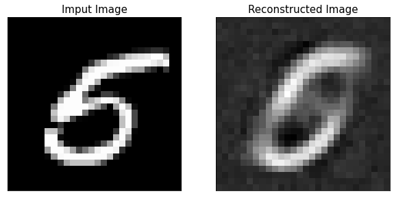

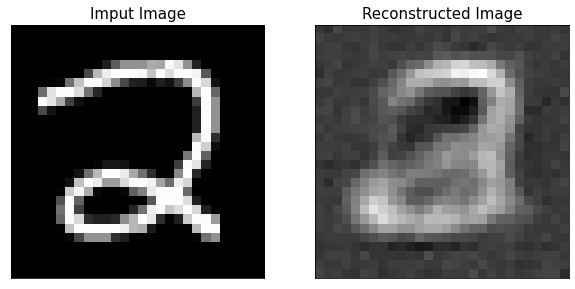

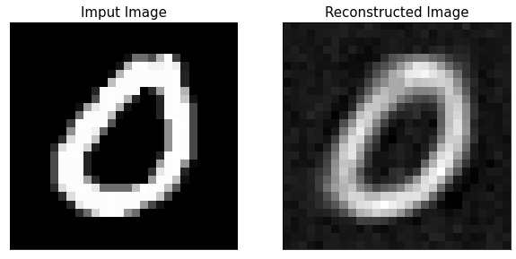

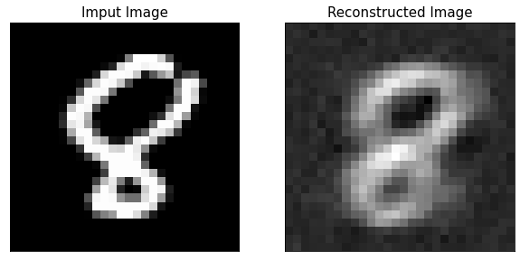

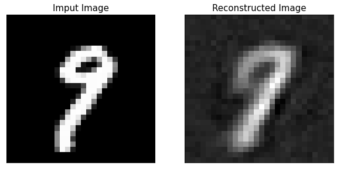

```python
# Solution

idxs = np.random.randint(0, test_imgs.shape[0], 5)

for idx in idxs:
    x_reconst = reg.predict(test_imgs[idx].reshape(-1,784))

    plt.figure(figsize = (10,8))
    plt.subplot(1,2,1)
    plt.imshow(test_imgs[idx].reshape(28,28), 'gray')
    plt.title('Imput Image', fontsize = 15)
    plt.xticks([])
    plt.yticks([])
    plt.subplot(1,2,2)
    plt.imshow(x_reconst.reshape(28,28), 'gray')
    plt.title('Reconstructed Image', fontsize = 15)
    plt.xticks([])
    plt.yticks([])
    plt.show()
```

3) Classify 10 digit classes by using MLP on latent space. Note that accurary above 65% is good enough.

```python
from sklearn.neural_network import MLPClassifier

mnist_train_images = np.load('./data_files/mnist_train_images_rev.npy')
mnist_train_labels = np.load('./data_files/mnist_train_labels_rev.npy')
mnist_test_images = np.load('./data_files/mnist_test_images_rev.npy')
mnist_test_labels = np.load('./data_files/mnist_test_labels_rev.npy')

train_labels = mnist_train_labels
train_imgs = mnist_train_images
test_labels = mnist_test_labels
test_imgs = mnist_test_images

def encoder(data):
    data = np.asmatrix(data)

    encoder1 = data*reg.coefs_[0] + reg.intercepts_[0]
    encoder1 = (np.exp(encoder1) - np.exp(-encoder1))/(np.exp(encoder1) + np.exp(-encoder1))

    encoder2 = encoder1*reg.coefs_[1] + reg.intercepts_[1]
    encoder2 = (np.exp(encoder2) - np.exp(-encoder2))/(np.exp(encoder2) + np.exp(-encoder2))

    latent = encoder2*reg.coefs_[2] + reg.intercepts_[2]
    latent = (np.exp(latent) - np.exp(-latent))/(np.exp(latent) + np.exp(-latent))

    return np.asarray(latent)

latent = []

for i in train_imgs:
    latent.append(encoder(i))

latent = np.asarray(latent).reshape(1000,n_latent)
```

```python
clf = MLPClassifier(solver = 'lbfgs',
                    activation = 'logistic',
                    alpha = 0.0,
                    hidden_layer_sizes = (50,),
                    learning_rate_init = 0.1,
                    max_iter = 1000,
                    random_state = 20,
                    verbose = True)

clf.fit(latent, train_labels)
```

```
MLPClassifier(activation='logistic', alpha=0.0, batch_size='auto', beta_1=0.9,
       beta_2=0.999, early_stopping=False, epsilon=1e-08,
       hidden_layer_sizes=(50,), learning_rate='constant',
       learning_rate_init=0.1, max_iter=1000, momentum=0.9,
       n_iter_no_change=10, nesterovs_momentum=True, power_t=0.5,
       random_state=20, shuffle=True, solver='lbfgs', tol=0.0001,
       validation_fraction=0.1, verbose=True, warm_start=False)
```

```python
test_latent = []

for i in test_imgs:
    test_latent.append(encoder(i))

test_latent = np.asarray(test_latent).reshape(100, n_latent)

prediction = clf.predict(test_latent)
acc = 0

for i, el in enumerate(test_labels):
    if el == prediction[i]:
        acc += 1

print('accuracy : ', acc)
```

```
accuracy :  70
```

# Problem 2

**PCA (Principal Component Analysis)**

- PCA is one of the oldest and most widely used dimensionality reduction algorithms. Its idea is to reduce the dimensionality of a dataset, while preserving as much 'variability' as possible. (but you don't need to fully understand the PCA algorithm for this problem.)

Actually, autoencoder is very similar to the PCA algorithm in terms of 'dimension reduction'. So, in this problem, we are going to build up PCA with autoencoder. While PCA is a linear dimension reduction method, the autoencoder has non-linear activation functions. Therefore, autoencoder without non-linear activation functions can be considered as PCA.

Now, we have 3D data. Run the below cell to load and 3D plot them.

**Data Download Link** (same)

- [Download data](https://www.dropbox.com/s/cjc6kewusii4ssl/pca_autoencoder.npy?dl=1)

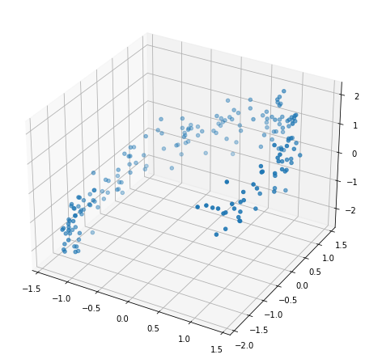

```python
import numpy as np
import matplotlib.pyplot as plt
from mpl_toolkits.mplot3d import Axes3D
%matplotlib inline

data = np.load('./data_files/pca_autoencoder.npy')

fig = plt.figure(figsize = (10, 8))
ax = fig.add_subplot(111, projection = '3d')
ax.scatter(data[:,0], data[:,1], data[:,2])
plt.show()

X_train, X_test = data[:100], data[100:]
```

PCA result in 2D is shown as follows.

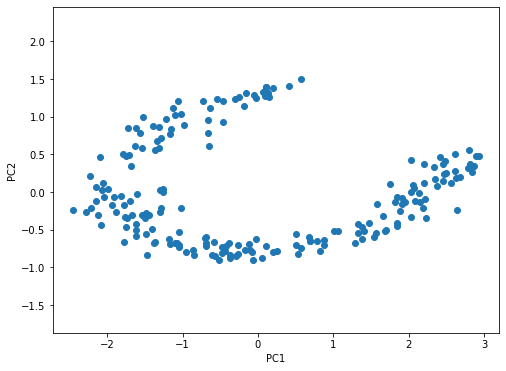

```python
from sklearn.decomposition import PCA

pca = PCA(n_components = 2)
pca.fit(data)
result = pca.transform(data)

plt.figure(figsize = (8, 6))
plt.plot(result[:,0], result[:,1], 'o')
plt.axis('equal')
plt.xlabel('PC1')
plt.ylabel('PC2')
plt.show()
```

(1) Design your linear autoencoder model using ANN. (freely design your own network structure)

```python
## Your code here
#
```

(2) After training your model, plot the data on latent space.

```python
## Your code here
#
```

# Solution 2

**PCA (Principal Component Analysis)**

- PCA is one of the oldest and most widely used dimensionality reduction algorithms. Its idea is to reduce the dimensionality of a dataset, while preserving as much 'variability' as possible. (but you don't need to fully understand the PCA algorithm for this problem.)

Actually, autoencoder is very similar to the PCA algorithm in terms of 'dimension reduction'. So, in this problem, we are going to build up PCA with autoencoder. While PCA is a linear dimension reduction method, the autoencoder has non-linear activation functions. Therefore, autoencoder without non-linear activation functions can be considered as PCA.

Now, we have 3D data. Run the below cell to load and 3D plot them.

**Data Download Link** (same)

- [Download data](https://www.dropbox.com/s/cjc6kewusii4ssl/pca_autoencoder.npy?dl=1)

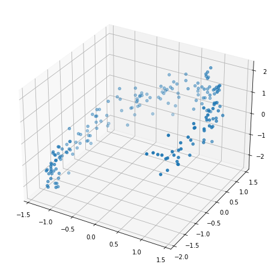

```python
import numpy as np
import matplotlib.pyplot as plt
from mpl_toolkits.mplot3d import Axes3D
%matplotlib inline

data = np.load('./data_files/pca_autoencoder.npy')

fig = plt.figure(figsize = (10, 8))
ax = fig.add_subplot(111, projection = '3d')
ax.scatter(data[:,0], data[:,1], data[:,2])
plt.show()

X_train, X_test = data[:100], data[100:]
```

PCA result in 2D is shown as follows.

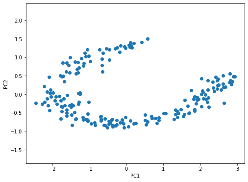

```python
from sklearn.decomposition import PCA

pca = PCA(n_components = 2)
pca.fit(data)
result = pca.transform(data)

plt.figure(figsize = (8, 6))
plt.plot(result[:,0], result[:,1], 'o')
plt.axis('equal')
plt.xlabel('PC1')
plt.ylabel('PC2')
plt.show()
```

(1) Design your linear autoencoder model using ANN. (freely design your own network structure)

```python
# Solution

from sklearn.neural_network import MLPRegressor

n_input = 3
n_latent = 2
n_output = n_input
```

```python
reg = MLPRegressor(hidden_layer_sizes = (n_latent,),
                   activation = 'identity',
                   solver = 'sgd',
                   learning_rate_init = 0.001,
                   max_iter = 500,
                   tol = 0.0000001,
                   verbose = False)
```

```python
reg.fit(X_train, X_train)
```

```
MLPRegressor(activation='identity', alpha=0.0001, batch_size='auto',
       beta_1=0.9, beta_2=0.999, early_stopping=False, epsilon=1e-08,
       hidden_layer_sizes=(2,), learning_rate='constant',
       learning_rate_init=0.001, max_iter=500, momentum=0.9,
       n_iter_no_change=10, nesterovs_momentum=True, power_t=0.5,
       random_state=None, shuffle=True, solver='sgd', tol=1e-07,
       validation_fraction=0.1, verbose=False, warm_start=False)
```

(2) After training your model, plot the data on latent space.

```python
def encoder(data):
    data = np.asmatrix(data)

    latent = data*reg.coefs_[0] + reg.intercepts_[0]

    return np.asarray(latent)
```

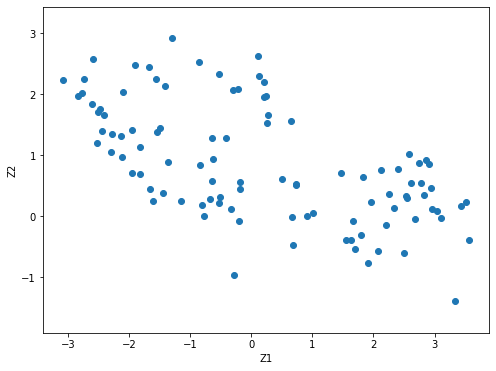

```python
test_latent = encoder(X_test)

plt.figure(figsize = (8, 6))
plt.scatter(test_latent[:,0], test_latent[:,1])
plt.axis('equal')
plt.xlabel('Z1')
plt.ylabel('Z2')
plt.show()
```

# Problem 4

The encoder part of an autoencoder is well known as a dimensionality reduction operator. This problem will ask you to implement the autoencoder algorithm for face data. The given data consists of 100 pictures of human faces with size of (50,40), we will apply an autoencoder to this dataset.

Download data from [here](https://www.dropbox.com/s/sane44unargfi0t/pca_faces.npy?dl=1).

```python
import matplotlib.pyplot as plt
import numpy as np
%matplotlib inline

data = np.load(open('./data_files/pca_faces.npy', 'rb'))
print(data.shape)
```

```
(100, 50, 40)
```

(a) Plot one random face out of 100 pictures. You might want to run multiple times to see what kinds of faces are in the data set.

```python
## write your code here
#

# plotting
plt.figure(figsize = (10,8))
plt.imshow(sample, 'gray')
plt.axis('off')
plt.show()
```

(b) Apply the autoencoder to the dataset. Build your model with the following structure:

- first encoder: 500
- second encoder: 300
- latent node: 8
- first decoder: 300
- second decoder: 500
- activation = 'relu'

```python
train_face = data.reshape([100, 50*40])
print(train_face.shape)
```

```
(100, 2000)
```

```python
## write your code here for training
#
```

```python
## write your code here to plot the reconstructed images of random input image
## Do not worry too much about poor reconstruction performance
#

# plotting
plt.figure(figsize = (15,12))
plt.subplot(1,2,1)
plt.imshow(test.reshape(50,40), 'gray')
plt.title('Input Image', fontsize = 15)
plt.xticks([])
plt.yticks([])
plt.subplot(1,2,2)
plt.imshow(recons.reshape(50,40), 'gray')
plt.title('Reconstructed Image', fontsize = 15)
plt.xticks([])
plt.yticks([])
plt.show()
```

(c) Reconstruct the face who wears a crown by your autoencoder and discuss the result of the reconstructed face. Do not worry too much about poor reconstruction performance.

```python
plt.figure(figsize = (10,8))
plt.imshow(data[94], 'gray')
plt.axis('off')
plt.show()
```

```python
## write your code here
#

# plotting
plt.figure(figsize = (15,12))
plt.subplot(1,2,1)
plt.imshow(test_face.reshape(50,40), 'gray')
plt.title('Input Image', fontsize = 15)
plt.xticks([])
plt.yticks([])
plt.subplot(1,2,2)
plt.imshow(recons.reshape(50,40), 'gray')
plt.title('Reconstructed Image', fontsize = 15)
plt.xticks([])
plt.yticks([])
plt.show()
```

(d) Reconstruct the face who wears sunglasses by your autoencoder and discuss the result of the reconstructed face. Do not worry too much about poor reconstruction performance.

```python
plt.figure(figsize = (10,8))
plt.imshow(data[28], 'gray')
plt.axis('off')
plt.show()
```

```python
## write your code here
## Do not worry too much about poor reconstruction performance
#

# plotting
plt.figure(figsize = (15,12))
plt.subplot(1,2,1)
plt.imshow(test_face.reshape(50,40), 'gray')
plt.title('Input Image', fontsize = 15)
plt.xticks([])
plt.yticks([])
plt.subplot(1,2,2)
plt.imshow(recons.reshape(50,40), 'gray')
plt.title('Reconstructed Image', fontsize = 15)
plt.xticks([])
plt.yticks([])
plt.show()
```

# Solution 4

The encoder part of an autoencoder is well known as a dimensionality reduction operator. This problem will ask you to implement the autoencoder algorithm for face data. The given data consists of 100 pictures of human faces with size of (50,40), we will apply an autoencoder to this dataset.

Download data from [here](https://www.dropbox.com/s/sane44unargfi0t/pca_faces.npy?dl=1).

```python
import matplotlib.pyplot as plt
import numpy as np
%matplotlib inline

data = np.load(open('./data_files/pca_faces.npy', 'rb'))
print(data.shape)
```

```
(100, 50, 40)
```

(a) Plot one random face out of 100 pictures. You might want to run multiple times to see what kinds of faces are in the data set.

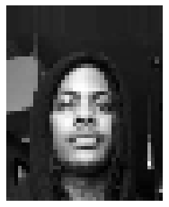

```python
sample = data[np.random.randint(0, 100)]
plt.imshow(sample, 'gray')
plt.axis('off')
plt.show()
```

(b) Apply the autoencoder to the dataset. Build your model with the following structure:

- first encoder: 500
- second encoder: 300
- latent node: 8
- first decoder: 300
- second decoder: 500

```python
train_face = data.reshape([100, 50*40])
print(train_face.shape)
```

```
(100, 2000)
```

```python
n_input = 50*40

# Encoder structure
n_encoder1 = 500
n_encoder2 = 300

n_latent = 8

# Decoder structure
n_decoder2 = 300
n_decoder1 = 500
```

```python
from sklearn.neural_network import MLPRegressor

reg = MLPRegressor(hidden_layer_sizes = (n_encoder1, n_encoder2, n_latent, n_decoder2, n_decoder1),
                   activation = 'relu',
                   learning_rate_init = 0.002,
                   max_iter = 1000,
                   random_state = 12,
                   verbose = True)

reg.fit(train_face, train_face)
```

```
Iteration 1, loss = 8224.54801954
Iteration 2, loss = 6168.32541029
Iteration 3, loss = 21956.65508318
Iteration 4, loss = 3248.17825196
Iteration 5, loss = 5492.70910835
Iteration 6, loss = 6035.34081419
Iteration 7, loss = 4686.32463643
Iteration 8, loss = 3295.17181022
Iteration 9, loss = 4400.72156491
Iteration 10, loss = 2513.84394050
Iteration 11, loss = 2198.00095337
Iteration 12, loss = 2302.33381112
Iteration 13, loss = 2042.23723107
Iteration 14, loss = 2019.59674569
Iteration 15, loss = 2388.23740555
Iteration 16, loss = 2148.64905570
Iteration 17, loss = 1972.10946499
Iteration 18, loss = 2085.86354011
Iteration 19, loss = 2045.12525678
Iteration 20, loss = 1846.77734998
Iteration 21, loss = 1847.36092136
Iteration 22, loss = 1960.43327300
Iteration 23, loss = 1825.46348628
Iteration 24, loss = 1768.56865139
Iteration 25, loss = 1847.20695693
Iteration 26, loss = 1827.73859767
Iteration 27, loss = 1737.11531791
Iteration 28, loss = 1760.99643649
Iteration 29, loss = 1808.57989932
Iteration 30, loss = 1739.37133550
Iteration 31, loss = 1727.19346971
Iteration 32, loss = 1770.89974677
Iteration 33, loss = 1746.96535117
Iteration 34, loss = 1707.36847221
Iteration 35, loss = 1737.58468569
Iteration 36, loss = 1729.35492127
Iteration 37, loss = 1695.87969822
Iteration 38, loss = 1709.79831557
Iteration 39, loss = 1716.45411153
Iteration 40, loss = 1695.35221716
```

[output cut: 327 more lines]

```
Iteration 368, loss = 1065.50969328
Iteration 369, loss = 1062.29954035
Iteration 370, loss = 1059.88242206
Iteration 371, loss = 1060.31345521
Iteration 372, loss = 1061.54730004
Iteration 373, loss = 1063.23897432
Iteration 374, loss = 1064.21081136
Iteration 375, loss = 1065.32734439
Iteration 376, loss = 1069.33134051
Iteration 377, loss = 1073.98869174
Iteration 378, loss = 1082.68132351
Iteration 379, loss = 1087.77872419
Iteration 380, loss = 1081.39722513
Iteration 381, loss = 1066.68507427
Training loss did not improve more than tol=0.000100 for 10 consecutive epochs. Stopping.
```

```
MLPRegressor(activation='relu', alpha=0.0001, batch_size='auto', beta_1=0.9,
       beta_2=0.999, early_stopping=False, epsilon=1e-08,
       hidden_layer_sizes=(500, 300, 8, 300, 500),
       learning_rate='constant', learning_rate_init=0.002, max_iter=1000,
       momentum=0.9, n_iter_no_change=10, nesterovs_momentum=True,
       power_t=0.5, random_state=12, shuffle=True, solver='adam',
       tol=0.0001, validation_fraction=0.1, verbose=True, warm_start=False)
```

```python
def test_batch(n_batch):
    idx = np.random.randint(len(train_face), size = n_batch)
    return train_face[idx]
```

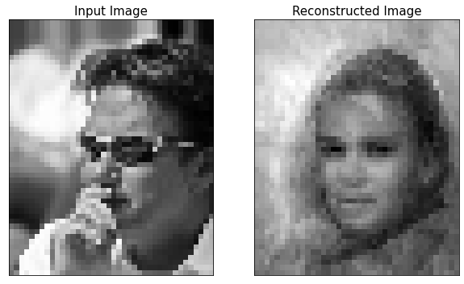

```python
test = test_batch(1)
recons = reg.predict(test.reshape(-1, 2000))

plt.figure(figsize = (10,8))
plt.subplot(1,2,1)
plt.imshow(test.reshape(50,40), 'gray')
plt.title('Input Image', fontsize = 15)
plt.xticks([])
plt.yticks([])
plt.subplot(1,2,2)
plt.imshow(recons.reshape(50,40), 'gray')
plt.title('Reconstructed Image', fontsize = 15)
plt.xticks([])
plt.yticks([])
plt.show()
```

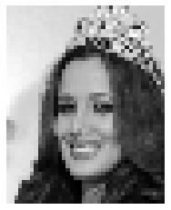

```python
plt.figure(figsize = (5,4))
plt.imshow(data[94], 'gray')
plt.axis('off')
plt.show()
```

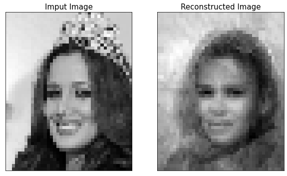

```python
test_face = data[94]
recons = reg.predict(test_face.reshape(-1,n_input))

plt.figure(figsize = (10,8))
plt.subplot(1,2,1)
plt.imshow(test_face.reshape(50,40), 'gray')
plt.title('Imput Image', fontsize = 15)
plt.xticks([])
plt.yticks([])
plt.subplot(1,2,2)
plt.imshow(recons.reshape(50,40), 'gray')
plt.title('Reconstructed Image', fontsize = 15)
plt.xticks([])
plt.yticks([])
plt.show()
```

(d) Reconstruct the face who wears sunglasses by your autoencoder and discuss the result of the reconstructed face. Do not worry too much about poor reconstruction performance.

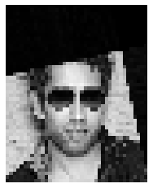

```python
plt.figure(figsize = (5,4))
plt.imshow(data[28], 'gray')
plt.axis('off')
plt.show()
```

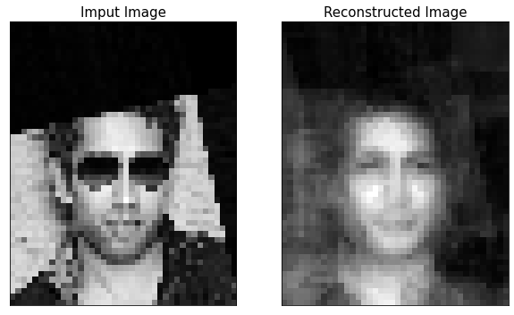

```python
test_face = data[28]
recons = reg.predict(test_face.reshape(-1,n_input))

plt.figure(figsize = (10,8))
plt.subplot(1,2,1)
plt.imshow(test_face.reshape(50,40), 'gray')
plt.title('Imput Image', fontsize = 15)
plt.xticks([])
plt.yticks([])
plt.subplot(1,2,2)
plt.imshow(recons.reshape(50,40), 'gray')
plt.title('Reconstructed Image', fontsize = 15)
plt.xticks([])
plt.yticks([])
plt.show()
```